# Intro to ggplot2

```r
acitelli <- read.csv("/Users/randigarcia/Desktop/Data/acitelli.csv", header=TRUE)
```

We first want to create a gender variable that is a character, this will make the output look nicer. We’ll make use of the `ifelse()` function inside of `mutate()`.

```r
library(dplyr)

acitelli <- acitelli %>%
  mutate(Gender = ifelse(gender == -1, "Women", "Men"))

menOnly <- acitelli %>%
  filter(gender == 1) %>%
  mutate(wise_hus = Yearsmar > median(Yearsmar)) %>%
  select(-gender)
```

# Visualizing Data

There are quite a few ways to make figures in R, we’ll the popular package `ggplot2`. You can find a cheat sheet for `ggplot2` [here](https://www.rstudio.com/wp-content/uploads/2016/11/ggplot2-cheatsheet-2.1.pdf). Be sure to install it first if you never have, or if you need to update it.

```r
#install.packages("ggplot2")
library(ggplot2)
```

## Quick Histogram

First, let’s make a histogram for `satisfaction`. The easiest way to make a figure with `ggplot2` is with the `qplot()` function. This stands for *quick plot*. Notice in the code below that we did not specify anything about a histogram. `qplot()` guesses which type of plot we want based on the variable’s type (i.e., integer, number, double, factor, character).

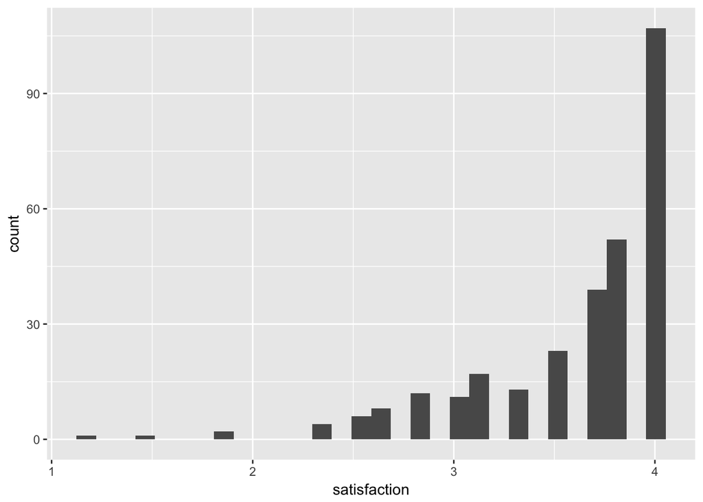

```r
qplot(satisfaction, data = acitelli)
```

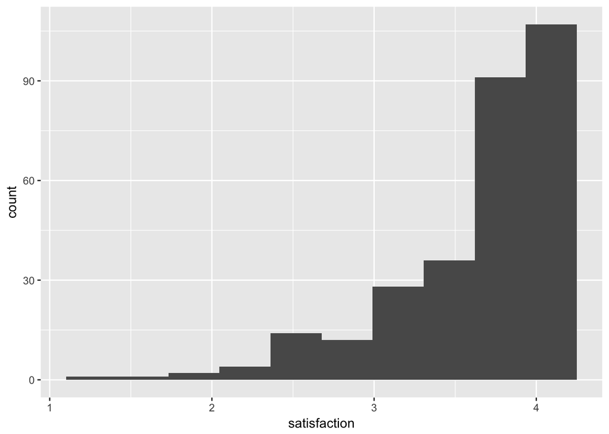

```r
qplot(satisfaction, data = acitelli, bins = 10)
```

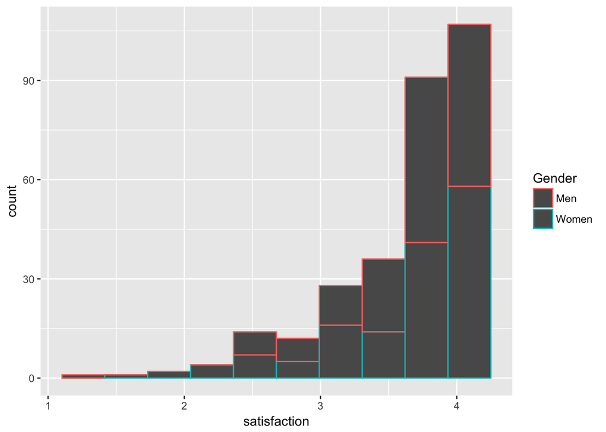

```r
qplot(x = satisfaction, color = Gender, data = acitelli, bins = 10)
```

## Quick Density Plot

An alternative to the histogram is the density plot. It displays a smoothed distribution and the area under the curve always sums to 1, thus, it’s good for comparing two groups with different n’s.

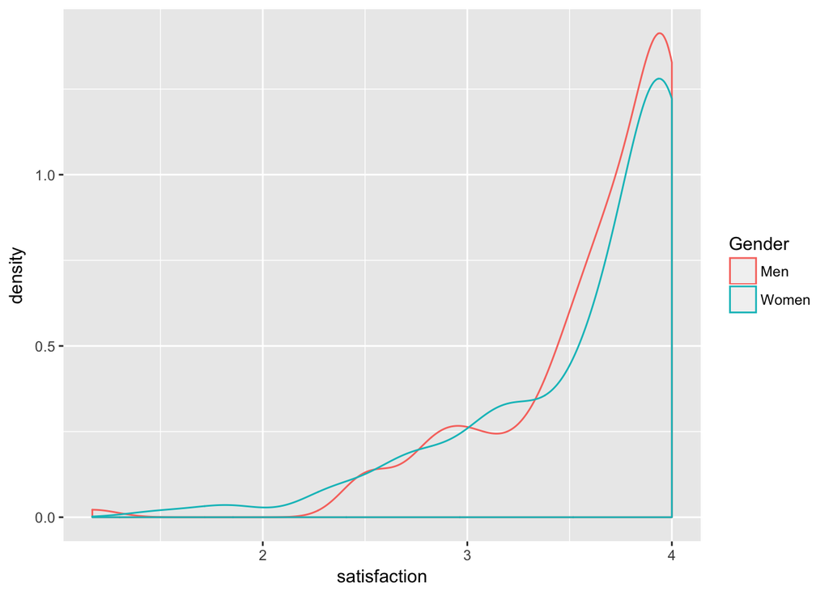

```r
qplot(x = satisfaction, color = Gender, data = acitelli, geom = "density")
```

## Quick Scatterplot

We might also want a scatter plot. Again,`qplot()` guesses what we want, but it’s a good idea to specify which variable goes on the x-axis and which goes on the y-axis.

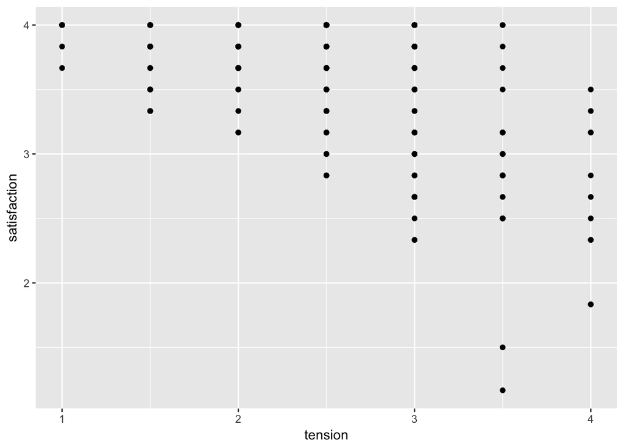

```r
qplot(x = tension, y = satisfaction, data = acitelli)
```

We can even add a third variable, mapping it to color. To get the behavior we want, gender has to be a categorical variable (a character variable is fine).

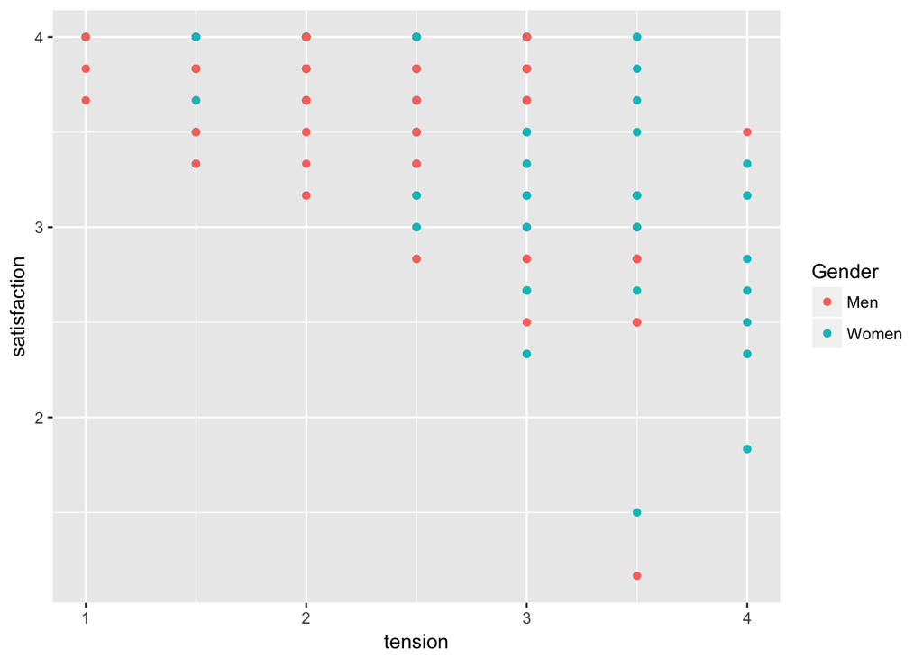

```r
qplot(x = tension, y = satisfaction, color = Gender, data = acitelli)
```

## Quick Boxplots

We can ask for side-by-side boxplots when our x variable is categorical. In this case `qplot()` does **NOT** know what to do, so we tell it we want boxplots with `geom = "boxplot"`.

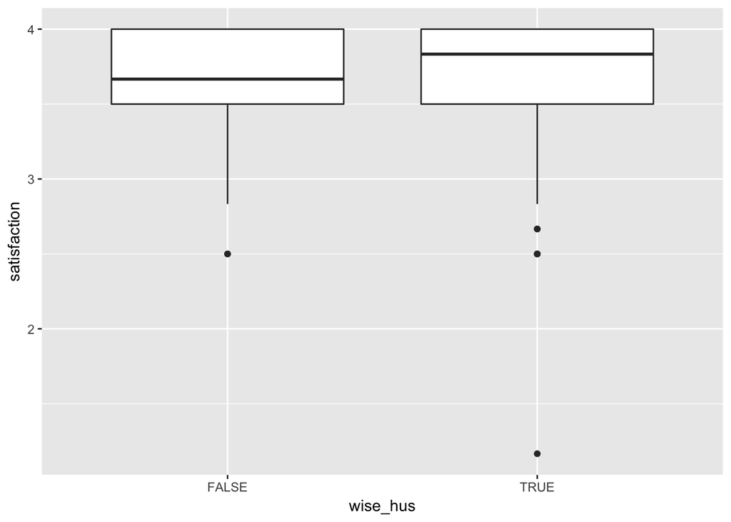

```r
qplot(y = satisfaction, x = wise_hus, data = menOnly, geom = "boxplot")
```